# Sociodemographic Fabric: Who Are the Workers in This Sample?

Binder 2 — Notebook 2 · CCHS Pooled 2010/11 + 2013/14

Author

Research Analyst

# Mission

Statistical models are only as interpretable as our understanding of *who* is in the sample. This notebook paints a sociodemographic portrait of the 63,843 employed Canadians in `cchs_analytical`, answering:

- What is the age, sex, education, income, immigration, and minority-status profile?
- Are these profiles consistent across the two survey cycles?
- How are employment type and work schedule distributed — and do they differ by sex?
- Which provinces contribute the most respondents, and is provincial representation stable across cycles?

# Environment

**Packages loaded for this notebook**

```r
library(magrittr)
library(ggplot2)
library(dplyr)
library(tidyr)
library(forcats)
library(scales)
library(arrow)
library(fs)

# httpgd for VS Code interactive plots (optional)
if (requireNamespace("httpgd", quietly = TRUE)) {
  tryCatch({
    if (is.function(httpgd::hgd)) httpgd::hgd() else httpgd::httpgd()
    message("httpgd started.")
  }, error = function(e) message("httpgd failed: ", conditionMessage(e)))
} else {
  message("httpgd not installed. Plots will use default device.")
}
```

**Project-level helper functions**

```r
base::source("./scripts/common-functions.R")
base::source("./scripts/operational-functions.R")
```

**Paths, palette, variable lists, province lookup**

```r
local_root    <- "./analysis/binder-2/"
local_data    <- paste0(local_root, "data-local/")
prints_folder <- paste0(local_root, "prints/")

if (!fs::dir_exists(local_data))    fs::dir_create(local_data)
if (!fs::dir_exists(prints_folder)) fs::dir_create(prints_folder)

# Wong colorblind-safe palette
clr <- c(
  orange    = "#E69F00",
  sky_blue  = "#56B4E9",
  green     = "#009E73",
  yellow    = "#F0E442",
  blue      = "#0072B2",
  vermillon = "#D55E00",
  pink      = "#CC79A7"
)

# Six demographic variables for the sociodemographic portrait
demo_vars <- c(
  "age_group", "sex", "education",
  "income_5cat", "immigration_status", "visible_minority"
)

demo_labels <- c(
  age_group          = "Age group",
  sex                = "Sex",
  education          = "Education",
  income_5cat        = "Household income",
  immigration_status = "Immigration status",
  visible_minority   = "Visible minority status"
)

# Province / territory lookup (Statistics Canada geodgprv codes)
province_lookup <- c(
  "10" = "NL", "11" = "PEI", "12" = "NS", "13" = "NB",
  "24" = "QC", "35" = "ON", "46" = "MB", "47" = "SK",
  "48" = "AB", "59" = "BC", "60" = "YK", "61" = "NWT", "62" = "NU"
)
```

**Load cchs_analytical.parquet**

```r
path_parquet <- "./data-private/derived/cchs-2-tables/cchs_analytical.parquet"
ds0 <- arrow::read_parquet(path_parquet)

message("Data loaded: ", nrow(ds0), " rows x ", ncol(ds0), " columns")
```

```
Data loaded: 63843 rows x 64 columns
```

**Add province label column from geodgprv codes**

```r
# Add province label column
ds0 <- ds0 %>%
  mutate(province = dplyr::recode(
    as.character(geodgprv),
    !!!province_lookup,
    .default = "Unknown"
  ))
```

# Data Context

For complete data documentation, see the Data Primer.

**Cycle breakdown table**

```r
cat("\nTable: cchs_analytical.parquet\n")
```

```
Table: cchs_analytical.parquet
```

**Cycle breakdown table**

```r
cat("  Grain: one row per survey respondent\n")
```

```
  Grain: one row per survey respondent
```

**Cycle breakdown table**

```r
cat("  Cycle 0 = CCHS 2010/2011 | Cycle 1 = CCHS 2013/2014\n\n")
```

```
  Cycle 0 = CCHS 2010/2011 | Cycle 1 = CCHS 2013/2014
```

**Cycle breakdown table**

```r
cat("Cycle breakdown:\n")
```

```
Cycle breakdown:
```

**Cycle breakdown table**

```r
ds0 %>%
  count(cycle_f) %>%
  mutate(pct = scales::percent(n / sum(n), accuracy = 0.1)) %>%
  print()
```

```
# A tibble: 2 × 3
  cycle_f            n pct
  <fct>          <int> <chr>
1 CCHS 2010-2011 32621 51.1%
2 CCHS 2013-2014 31222 48.9%
```

**Representative respondent — one row per cycle**

```r
cat("\nRepresentative respondent — one row per cycle:\n")
```

```
Representative respondent — one row per cycle:
```

**Representative respondent — one row per cycle**

```r
ds0 %>%
  group_by(cycle_f) %>%
  slice(1) %>%
  ungroup() %>%
  select(cycle_f, age_group, sex, education, income_5cat,
         employment_type, work_schedule, province) %>%
  print()
```

```
# A tibble: 2 × 8
  cycle_f    age_group sex   education income_5cat employment_type work_schedule
  <fct>      <ord>     <fct> <ord>     <ord>       <fct>           <fct>
1 CCHS 2010… 15-24     Fema… Post-sec… <NA>        Employee        Part-time
2 CCHS 2013… 55-75     Male  Post-sec… $40k - $59… Self-employed   Full-time
# ℹ 1 more variable: province <chr>
```

**Quick-look: age group and sex distributions**

```r
cat("\nAge group distribution (pooled):\n")
```

```
Age group distribution (pooled):
```

**Quick-look: age group and sex distributions**

```r
ds0 %>%
  count(age_group) %>%
  mutate(pct = scales::percent(n / sum(n), accuracy = 0.1)) %>%
  print()
```

```
# A tibble: 3 × 3
  age_group     n pct
  <ord>     <int> <chr>
1 15-24      9662 15.1%
2 25-54     37101 58.1%
3 55-75     17080 26.8%
```

**Quick-look: age group and sex distributions**

```r
cat("\nSex distribution (pooled):\n")
```

```
Sex distribution (pooled):
```

**Quick-look: age group and sex distributions**

```r
ds0 %>%
  count(sex) %>%
  mutate(pct = scales::percent(n / sum(n), accuracy = 0.1)) %>%
  print()
```

```
# A tibble: 2 × 3
  sex        n pct
  <fct>  <int> <chr>
1 Male   31540 49.4%
2 Female 32303 50.6%
```

# Analysis

## Six-Dimension Demographic Portrait (g1 family)

`g1` assembles six demographic variables into a single faceted view — one panel per variable, bars sorted by frequency. This is the fastest way to read the sample composition without flipping between six separate charts.

`g11` layers in the cycle dimension: parallel bars per level let the analyst check whether demographic proportions shifted between 2010/11 and 2013/14. Large discrepancies would warrant investigation before pooling.

**Pivot 6 demographic vars into long format; compute proportions**

```r
# Six demographic dimensions as a long table suitable for faceted small-multiples
g1_data <- ds0 %>%
  select(all_of(demo_vars), cycle_f) %>%
  pivot_longer(all_of(demo_vars),
               names_to = "variable",
               values_to = "level",
               values_transform = list(level = as.character)) %>%
  mutate(level = as.character(level)) %>%
  filter(!is.na(level)) %>%
  group_by(variable, level) %>%
  summarise(n = n(), .groups = "drop_last") %>%
  mutate(pct = n / sum(n)) %>%
  ungroup() %>%
  mutate(
    variable = factor(variable, levels = demo_vars, labels = unname(demo_labels))
  )
```

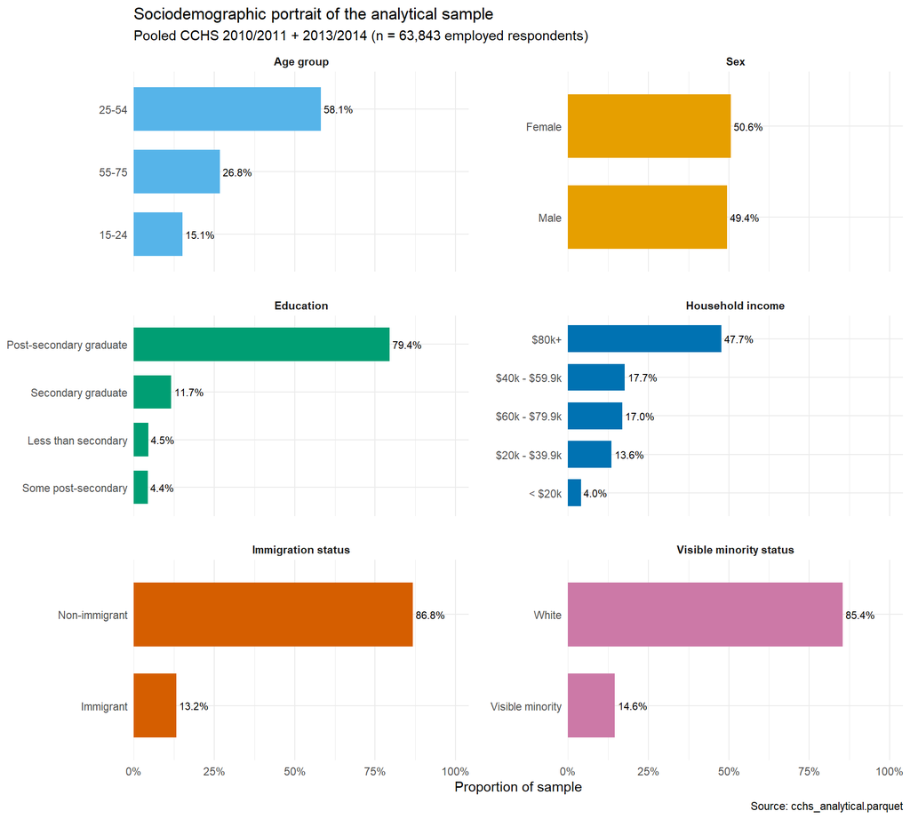

Sociodemographic portrait of the pooled analytical sample. Six demographic variables displayed as faceted horizontal bars.

```r
# Faceted horizontal bars — pooled sample proportions across 6 demographic vars
g1_demo_portrait <- g1_data %>%
  ggplot(aes(x = pct,
             y = fct_reorder(level, pct),
             fill = variable)) +
  geom_col(width = 0.7, show.legend = FALSE) +
  geom_text(aes(label = scales::percent(pct, accuracy = 0.1)),
            hjust = -0.1, size = 2.9) +
  facet_wrap(~variable, scales = "free_y", ncol = 2) +
  scale_x_continuous(
    labels = scales::percent_format(accuracy = 1),
    expand = expansion(mult = c(0, 0.20))
  ) +
  scale_fill_manual(values = unname(clr[c(
    "sky_blue", "orange", "green", "blue", "vermillon", "pink"
  )])) +
  labs(
    title   = "Sociodemographic portrait of the analytical sample",
    subtitle = "Pooled CCHS 2010/2011 + 2013/2014 (n = 63,843 employed respondents)",
    x       = "Proportion of sample",
    y       = NULL,
    caption = "Source: cchs_analytical.parquet"
  ) +
  theme_minimal(base_size = 11) +
  theme(
    strip.text    = element_text(face = "bold"),
    panel.spacing = unit(1.2, "lines")
  )

ggsave(paste0(prints_folder, "g1_demo_portrait.png"),
       g1_demo_portrait, width = 8.5, height = 9, dpi = 300)
print(g1_demo_portrait)
```

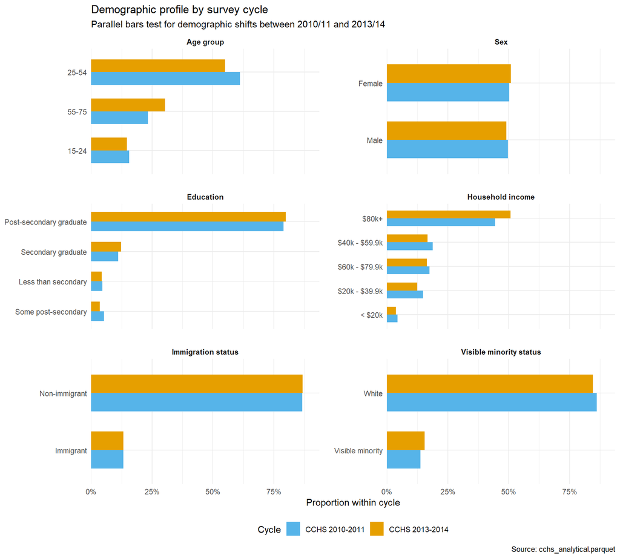

Demographic profile by survey cycle — bars coloured by cycle test for cross-cycle consistency.

```r
# Same six variables, split by cycle — cross-cycle demographic consistency check
g11_data <- ds0 %>%
  select(all_of(demo_vars), cycle_f) %>%
  pivot_longer(all_of(demo_vars),
               names_to = "variable",
               values_to = "level",
               values_transform = list(level = as.character)) %>%
  mutate(level = as.character(level)) %>%
  filter(!is.na(level)) %>%
  group_by(cycle_f, variable, level) %>%
  summarise(n = n(), .groups = "drop_last") %>%
  mutate(pct = n / sum(n)) %>%
  ungroup() %>%
  mutate(
    variable = factor(variable, levels = demo_vars, labels = unname(demo_labels))
  )

g11_cycle_consistency <- g11_data %>%
  ggplot(aes(x = pct,
             y = fct_reorder(level, pct),
             fill = cycle_f)) +
  geom_col(position = "dodge", width = 0.65) +
  facet_wrap(~variable, scales = "free_y", ncol = 2) +
  scale_x_continuous(
    labels = scales::percent_format(accuracy = 1),
    expand = expansion(mult = c(0, 0.08))
  ) +
  scale_fill_manual(values = unname(c(clr["sky_blue"], clr["orange"]))) +
  labs(
    title   = "Demographic profile by survey cycle",
    subtitle = "Parallel bars test for demographic shifts between 2010/11 and 2013/14",
    x       = "Proportion within cycle",
    y       = NULL,
    fill    = "Cycle",
    caption = "Source: cchs_analytical.parquet"
  ) +
  theme_minimal(base_size = 11) +
  theme(
    strip.text      = element_text(face = "bold"),
    legend.position = "bottom",
    panel.spacing   = unit(1.2, "lines")
  )

ggsave(paste0(prints_folder, "g11_cycle_consistency.png"),
       g11_cycle_consistency, width = 8.5, height = 9, dpi = 300)
print(g11_cycle_consistency)
```

## Employment Structure (g2 family)

**Employment type × work schedule cross-tab**

```r
# Employment type × work schedule cross-tabulation
# droplevels() removes factor levels with zero observations (e.g. "Unpaid family worker")
g2_data <- ds0 %>%
  filter(!is.na(employment_type), !is.na(work_schedule)) %>%
  droplevels() %>%
  count(employment_type, work_schedule) %>%
  group_by(employment_type) %>%
  mutate(pct_within = n / sum(n)) %>%
  ungroup()
```

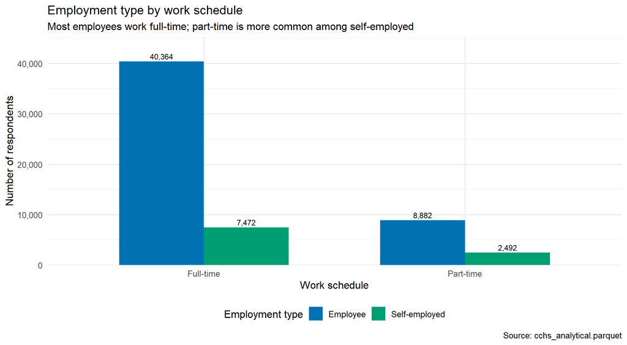

```r
# Grouped bar: employment type × work schedule (absolute counts)
g2_employment_schedule <- g2_data %>%
  ggplot(aes(x = work_schedule, y = n, fill = employment_type)) +
  geom_col(position = "dodge", width = 0.65) +
  geom_text(aes(label = scales::comma(n)),
            position = position_dodge(width = 0.65),
            vjust = -0.4, size = 3) +
  scale_y_continuous(
    labels = scales::comma,
    expand = expansion(mult = c(0, 0.12))
  ) +
  scale_fill_manual(values = setNames(
    unname(clr[c("blue", "green", "orange")])[seq_along(levels(g2_data$employment_type))],
    levels(g2_data$employment_type)
  )) +
  labs(
    title   = "Employment type by work schedule",
    subtitle = "Most employees work full-time; part-time is more common among self-employed",
    x       = "Work schedule",
    y       = "Number of respondents",
    fill    = "Employment type",
    caption = "Source: cchs_analytical.parquet"
  ) +
  theme_minimal(base_size = 12) +
  theme(legend.position = "bottom")

ggsave(paste0(prints_folder, "g2_employment_schedule.png"),
       g2_employment_schedule, width = 8.5, height = 5.5, dpi = 300)
print(g2_employment_schedule)
```

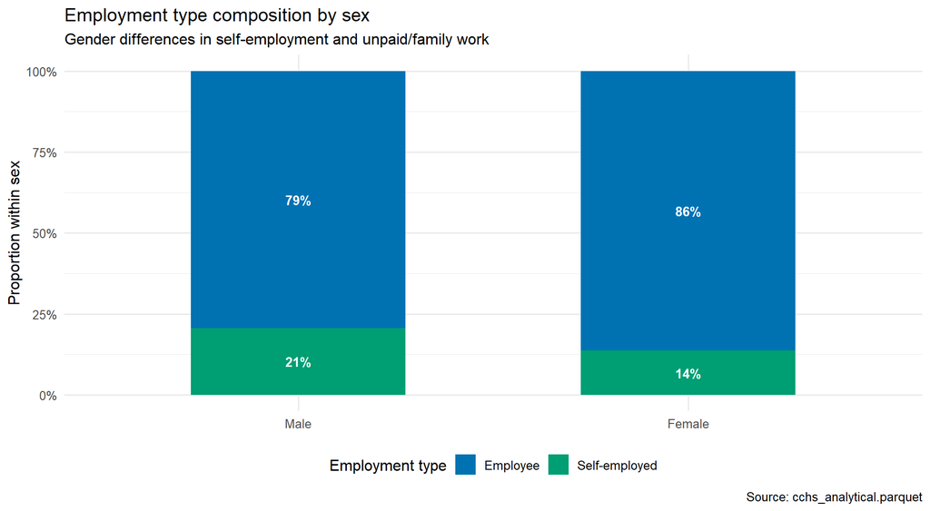

Employment type composition by sex. Stacked proportions reveal gender differences in self-employment.

```r
# Employment type composition by sex — stacked proportions
g21_employment_by_sex <- ds0 %>%
  filter(!is.na(employment_type), !is.na(sex)) %>%
  droplevels() %>%
  count(sex, employment_type) %>%
  group_by(sex) %>%
  mutate(pct = n / sum(n)) %>%
  ungroup() %>%
  ggplot(aes(x = sex, y = pct, fill = employment_type)) +
  geom_col(width = 0.55) +
  geom_text(aes(label = scales::percent(pct, accuracy = 1)),
            position = position_stack(vjust = 0.5),
            colour = "white", size = 3.5, fontface = "bold") +
  scale_y_continuous(labels = scales::percent_format()) +
  scale_fill_manual(values = setNames(
    unname(clr[c("blue", "green", "orange")])[seq_along(levels(g2_data$employment_type))],
    levels(g2_data$employment_type)
  )) +
  labs(
    title   = "Employment type composition by sex",
    subtitle = "Gender differences in self-employment and unpaid/family work",
    x       = NULL,
    y       = "Proportion within sex",
    fill    = "Employment type",
    caption = "Source: cchs_analytical.parquet"
  ) +
  theme_minimal(base_size = 12) +
  theme(legend.position = "bottom")

ggsave(paste0(prints_folder, "g21_employment_by_sex.png"),
       g21_employment_by_sex, width = 6.5, height = 5.5, dpi = 300)
print(g21_employment_by_sex)
```

## Geographic Distribution (g3 family)

`g3` ranks provinces by total respondent count — a quick read of where the analytical power lives.

`g31` checks cycle-to-cycle provincial balance: if provincial shares are stable across cycles, the pooled design is defensible. Substantial deviations would suggest either targeted oversampling in one cycle or changes in frame coverage.

**Province distribution, total and by cycle**

```r
# Province distribution — total and by cycle
g3_data <- ds0 %>%
  filter(province != "Unknown") %>%
  count(province, cycle_f) %>%
  group_by(cycle_f) %>%
  mutate(pct_within_cycle = n / sum(n)) %>%
  ungroup()
```

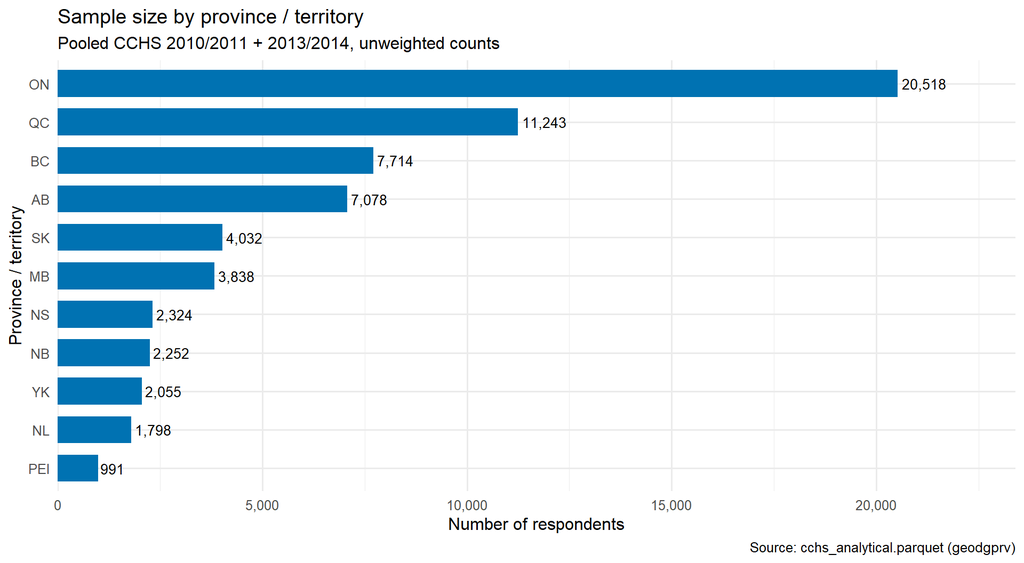

Sample size by province / territory, pooled. Sorted by total count.

```r
# Horizontal bar: total sample by province, sorted
g3_province <- g3_data %>%
  group_by(province) %>%
  summarise(n_total = sum(n), .groups = "drop") %>%
  ggplot(aes(x = n_total, y = fct_reorder(province, n_total))) +
  geom_col(fill = clr["blue"], width = 0.7) +
  geom_text(aes(label = scales::comma(n_total)), hjust = -0.1, size = 3.5) +
  scale_x_continuous(
    labels = scales::comma,
    expand = expansion(mult = c(0, 0.14))
  ) +
  labs(
    title   = "Sample size by province / territory",
    subtitle = "Pooled CCHS 2010/2011 + 2013/2014, unweighted counts",
    x       = "Number of respondents",
    y       = "Province / territory",
    caption = "Source: cchs_analytical.parquet (geodgprv)"
  ) +
  theme_minimal(base_size = 12)

ggsave(paste0(prints_folder, "g3_province.png"),
       g3_province, width = 8.5, height = 5.5, dpi = 300)
print(g3_province)
```

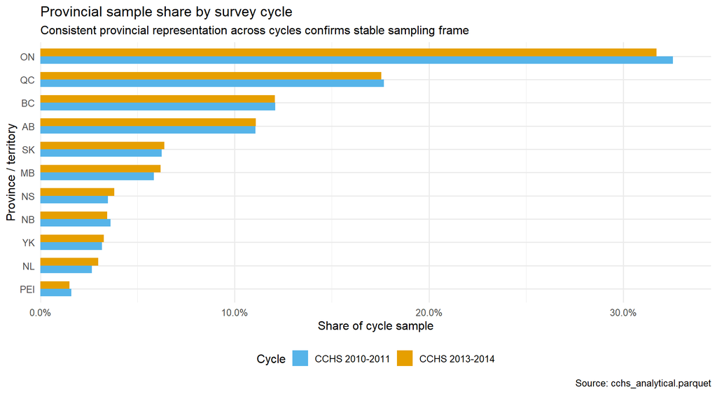

Provincial share within each cycle. Consistent proportions across cycles support pooling.

```r
# Province × cycle balance — same provinces should have similar shares each cycle
g31_province_cycle <- g3_data %>%
  ggplot(aes(x = pct_within_cycle,
             y = fct_reorder(province, pct_within_cycle),
             fill = cycle_f)) +
  geom_col(position = "dodge", width = 0.65) +
  scale_x_continuous(
    labels = scales::percent_format(accuracy = 0.1),
    expand = expansion(mult = c(0, 0.06))
  ) +
  scale_fill_manual(values = unname(c(clr["sky_blue"], clr["orange"]))) +
  labs(
    title   = "Provincial sample share by survey cycle",
    subtitle = "Consistent provincial representation across cycles confirms stable sampling frame",
    x       = "Share of cycle sample",
    y       = "Province / territory",
    fill    = "Cycle",
    caption = "Source: cchs_analytical.parquet"
  ) +
  theme_minimal(base_size = 12) +
  theme(legend.position = "bottom")

ggsave(paste0(prints_folder, "g31_province_cycle.png"),
       g31_province_cycle, width = 8.5, height = 5.5, dpi = 300)
print(g31_province_cycle)
```

```r
# nolint end
```

# Feedback Questions

1. **Sole PUMF gap**: `student_status` is the only ALL-NA column in this dataset. Given that student status may interact with employment type and work schedule (part-time students vs. full-time workers), would you pursue an alternative operationalization from existing variables (e.g., age + education combination) or flag this as an unavoidable PUMF limitation?
2. **Cycle consistency**: Looking at `g11`, is any demographic shift between 2010/11 and 2013/14 large enough to warrant a cycle-by-covariate interaction term in the regression model, or are the differences analytically negligible?
3. **Employment type composition**: The sample contains only Employees (78%) and Self-employed (16%), with zero observations for “Unpaid family worker” (phantom PUMF level). Given this de facto binary split, should `employment_type` be simplified to a 2-level factor, or would you retain the original 3-level coding to accommodate potential future data linkage?